# My Heavy Caffeine Habit: Why I drink it and what it’s costing me

## What is this data about?

For two weeks, for every single one of the over 40 caffeinated drinks that I drank I responded to a number of questions and have been able to make a quite the number of observations from observing myself. I recorded, the drink type, cost, my mood before drinking, the day of the week, and what number drink it was for that day.

This story explores when and why I reach for caffeine, how my current mood drives my choices and what the habit of all of these drinks every day ends up costing me.

## What mood am I in before I reach for caffeine?

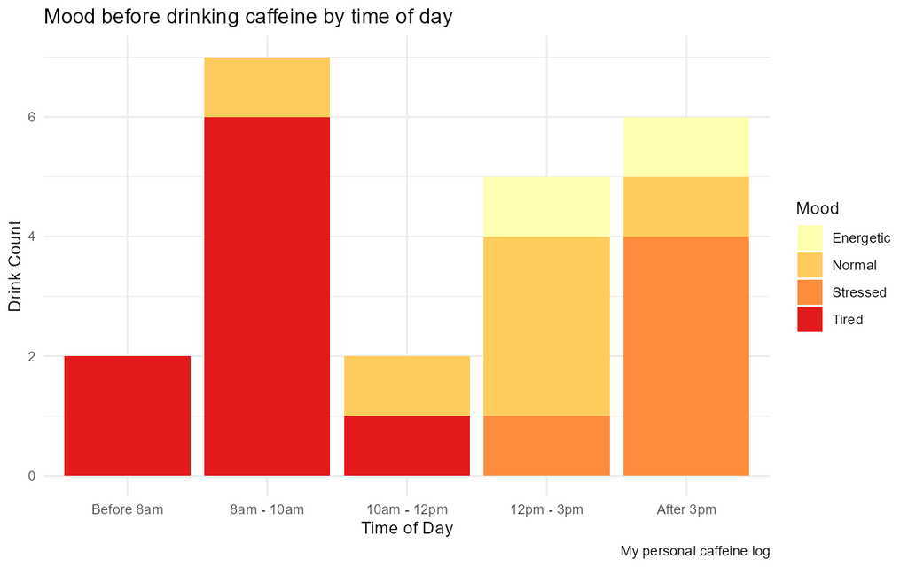

A stacked bar chart showing mood before drinking caffeine by time of day

The mood before gulping down caffeine in the morning was predictably consistently tired. Interestingly the mood that dominated after 3pm was stressed, perhaps as a result of drinking too much caffeine through the day or something to do with my preference for drinking a cup of tea during the day when stressed, although I would’ve thought that I would be more stressed between 12pm-3pm when I do drink tea as well if that were the case.

## Which drinks cost me the most on average?

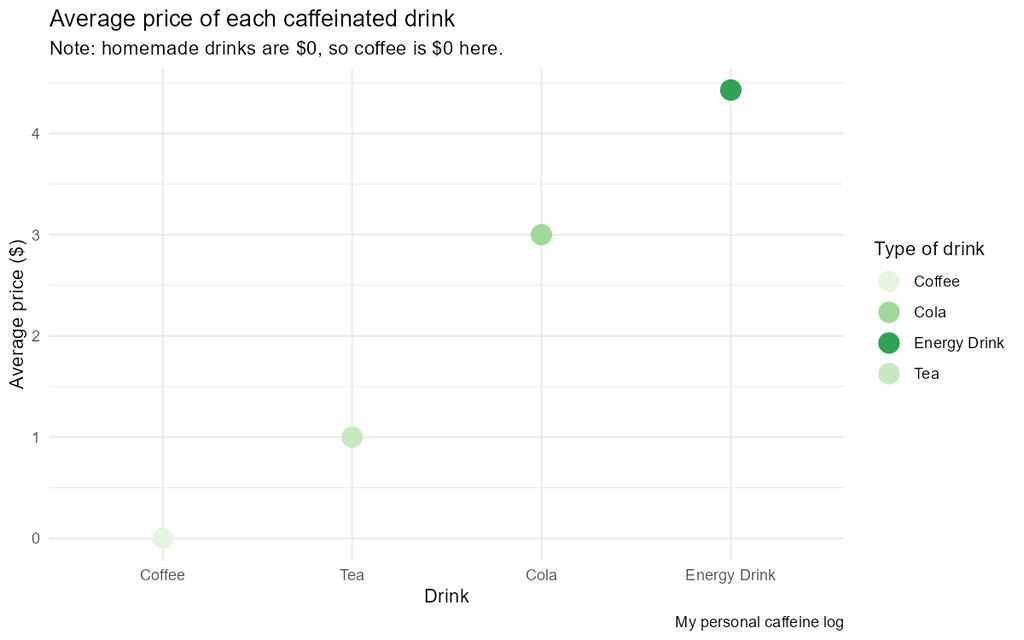

A dot plot showing average cost of each type of drink

Instant coffee doesn’t cost me anything since I just make it up at home, same for most of the tea I drink. Energy drinks are clearly the most expensive choice being about $4.50 as can be seen in the dot plot in front of cola sitting at around $3. If I could fully make the switch from energy drinks to coffee it would save me about $31.50 every week which is a monster $1638 a year! Not counting all of that cola!

## Is my caffeine intake increase week to week?

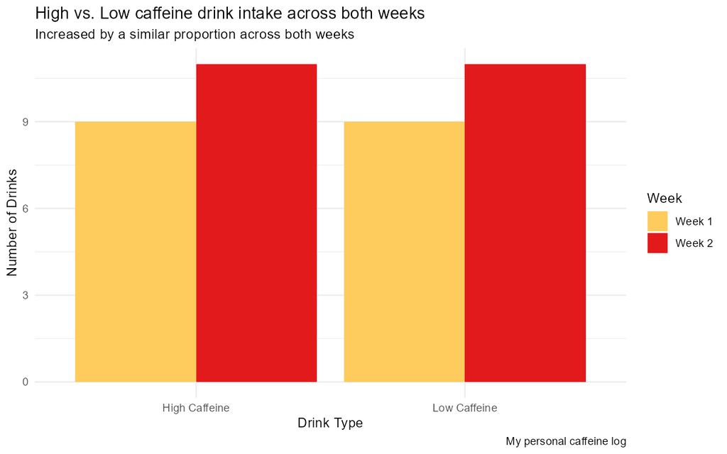

A bar chart showing high caffeine and low caffeine drink intake from week 1 to 2

## How much did all of this caffeine cost me?

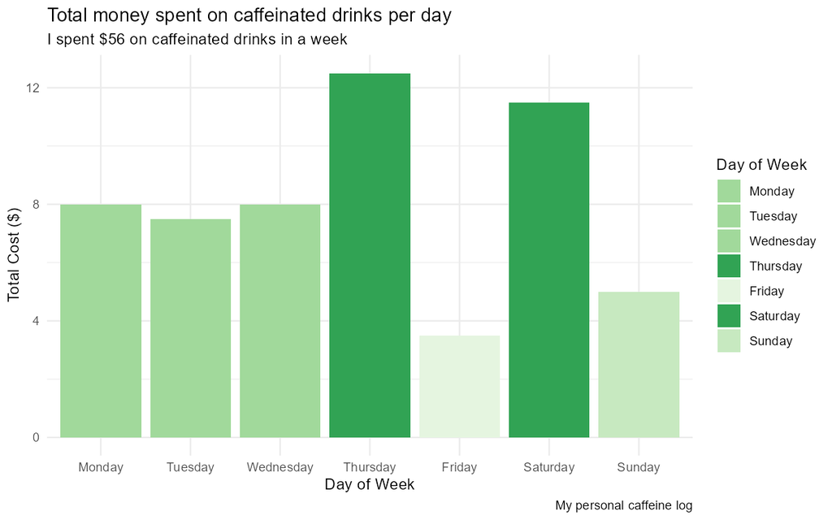

A bar chart showing how much is spent per day in the second week

The amount spent per day changed depending on whether I chose to drink homemade drinks like coffee and tea compared to going out and buying energy drinks, ice tea and cola. I noticed that the days with higher spending usually coincided with the days that I was much busier and more convenient. In total over the course of the week I spent $56 on caffeinated drinks. If I spent that much on caffeinated drinks every week, which I probably am, I’m spending $2912 a year! Even though I really love caffeine this seriously makes me want to switch to instant coffee over energy drinks.